# Risk Factor Analysis

## Outcome Variable

**Outcome Variable:** wast_rec90d

## Predictor Variables

**Intervention Variable:** nrooms

**Adjustment Set:**

- arm
- sex
- W_mage
- meducyrs
- feducyrs
- hhwealth_quart
- hfoodsec
- W_mhtcm
- W_nchldlt5
- W_parity
- impfloor
- impsan
- safeh20
- delta_W_mage
- delta_meducyrs
- delta_feducyrs
- delta_hhwealth_quart
- delta_hfoodsec
- delta_W_mhtcm
- delta_W_nchldlt5
- delta_W_parity
- delta_impfloor
- delta_impsan
- delta_safeh20

## Stratifying Variables

The analysis was stratified on these variable(s):

- agecat
- studyid
- country

## Data Summary

| agecat | studyid | country | nrooms | wast_rec90d | n_cell | n |
| --- | --- | --- | --- | --- | --- | --- |
| 0-24 months | ki0047075b-MAL-ED | BANGLADESH | 4+ | 0 | 3 | 121 |
| 0-24 months | ki0047075b-MAL-ED | BANGLADESH | 4+ | 1 | 1 | 121 |
| 0-24 months | ki0047075b-MAL-ED | BANGLADESH | 1 | 0 | 32 | 121 |
| 0-24 months | ki0047075b-MAL-ED | BANGLADESH | 1 | 1 | 61 | 121 |
| 0-24 months | ki0047075b-MAL-ED | BANGLADESH | 2 | 0 | 7 | 121 |
| 0-24 months | ki0047075b-MAL-ED | BANGLADESH | 2 | 1 | 9 | 121 |
| 0-24 months | ki0047075b-MAL-ED | BANGLADESH | 3 | 0 | 2 | 121 |
| 0-24 months | ki0047075b-MAL-ED | BANGLADESH | 3 | 1 | 6 | 121 |
| 0-24 months | ki0047075b-MAL-ED | BRAZIL | 4+ | 0 | 5 | 23 |
| 0-24 months | ki0047075b-MAL-ED | BRAZIL | 4+ | 1 | 12 | 23 |
| 0-24 months | ki0047075b-MAL-ED | BRAZIL | 1 | 0 | 0 | 23 |
| 0-24 months | ki0047075b-MAL-ED | BRAZIL | 1 | 1 | 0 | 23 |
| 0-24 months | ki0047075b-MAL-ED | BRAZIL | 2 | 0 | 0 | 23 |
| 0-24 months | ki0047075b-MAL-ED | BRAZIL | 2 | 1 | 2 | 23 |
| 0-24 months | ki0047075b-MAL-ED | BRAZIL | 3 | 0 | 1 | 23 |
| 0-24 months | ki0047075b-MAL-ED | BRAZIL | 3 | 1 | 3 | 23 |
| 0-24 months | ki0047075b-MAL-ED | INDIA | 4+ | 0 | 3 | 173 |
| 0-24 months | ki0047075b-MAL-ED | INDIA | 4+ | 1 | 9 | 173 |
| 0-24 months | ki0047075b-MAL-ED | INDIA | 1 | 0 | 27 | 173 |
| 0-24 months | ki0047075b-MAL-ED | INDIA | 1 | 1 | 38 | 173 |
| 0-24 months | ki0047075b-MAL-ED | INDIA | 2 | 0 | 23 | 173 |
| 0-24 months | ki0047075b-MAL-ED | INDIA | 2 | 1 | 41 | 173 |
| 0-24 months | ki0047075b-MAL-ED | INDIA | 3 | 0 | 14 | 173 |
| 0-24 months | ki0047075b-MAL-ED | INDIA | 3 | 1 | 18 | 173 |
| 0-24 months | ki0047075b-MAL-ED | NEPAL | 4+ | 0 | 14 | 92 |
| 0-24 months | ki0047075b-MAL-ED | NEPAL | 4+ | 1 | 39 | 92 |
| 0-24 months | ki0047075b-MAL-ED | NEPAL | 1 | 0 | 4 | 92 |
| 0-24 months | ki0047075b-MAL-ED | NEPAL | 1 | 1 | 23 | 92 |
| 0-24 months | ki0047075b-MAL-ED | NEPAL | 2 | 0 | 1 | 92 |
| 0-24 months | ki0047075b-MAL-ED | NEPAL | 2 | 1 | 5 | 92 |

[output cut: 354 more lines]

The following strata were considered:

- agecat: 0-24 months, studyid: ki0047075b-MAL-ED, country: BANGLADESH
- agecat: 0-24 months, studyid: ki0047075b-MAL-ED, country: BRAZIL
- agecat: 0-24 months, studyid: ki0047075b-MAL-ED, country: INDIA
- agecat: 0-24 months, studyid: ki0047075b-MAL-ED, country: NEPAL
- agecat: 0-24 months, studyid: ki0047075b-MAL-ED, country: PERU
- agecat: 0-24 months, studyid: ki0047075b-MAL-ED, country: SOUTH AFRICA
- agecat: 0-24 months, studyid: ki0047075b-MAL-ED, country: TANZANIA, UNITED REPUBLIC OF
- agecat: 0-24 months, studyid: ki1000108-CMC-V-BCS-2002, country: INDIA
- agecat: 0-24 months, studyid: ki1000108-IRC, country: INDIA
- agecat: 0-24 months, studyid: ki1017093b-PROVIDE, country: BANGLADESH
- agecat: 0-24 months, studyid: ki1017093c-NIH-Crypto, country: BANGLADESH
- agecat: 0-24 months, studyid: ki1113344-GMS-Nepal, country: NEPAL
- agecat: 0-24 months, studyid: ki1114097-CONTENT, country: PERU
- agecat: 0-24 months, studyid: ki1135781-COHORTS, country: INDIA
- agecat: 0-24 months, studyid: kiGH5241-JiVitA-3, country: BANGLADESH
- agecat: 0-24 months, studyid: kiGH5241-JiVitA-4, country: BANGLADESH
- agecat: 0-6 months, studyid: ki0047075b-MAL-ED, country: BANGLADESH
- agecat: 0-6 months, studyid: ki0047075b-MAL-ED, country: BRAZIL
- agecat: 0-6 months, studyid: ki0047075b-MAL-ED, country: INDIA
- agecat: 0-6 months, studyid: ki0047075b-MAL-ED, country: NEPAL
- agecat: 0-6 months, studyid: ki0047075b-MAL-ED, country: PERU
- agecat: 0-6 months, studyid: ki0047075b-MAL-ED, country: SOUTH AFRICA
- agecat: 0-6 months, studyid: ki0047075b-MAL-ED, country: TANZANIA, UNITED REPUBLIC OF
- agecat: 0-6 months, studyid: ki1000108-CMC-V-BCS-2002, country: INDIA
- agecat: 0-6 months, studyid: ki1000108-IRC, country: INDIA
- agecat: 0-6 months, studyid: ki1017093b-PROVIDE, country: BANGLADESH
- agecat: 0-6 months, studyid: ki1017093c-NIH-Crypto, country: BANGLADESH
- agecat: 0-6 months, studyid: ki1113344-GMS-Nepal, country: NEPAL
- agecat: 0-6 months, studyid: ki1114097-CONTENT, country: PERU
- agecat: 0-6 months, studyid: ki1135781-COHORTS, country: INDIA
- agecat: 0-6 months, studyid: kiGH5241-JiVitA-3, country: BANGLADESH
- agecat: 0-6 months, studyid: kiGH5241-JiVitA-4, country: BANGLADESH
- agecat: 6-24 months, studyid: ki0047075b-MAL-ED, country: BANGLADESH
- agecat: 6-24 months, studyid: ki0047075b-MAL-ED, country: BRAZIL
- agecat: 6-24 months, studyid: ki0047075b-MAL-ED, country: INDIA
- agecat: 6-24 months, studyid: ki0047075b-MAL-ED, country: NEPAL
- agecat: 6-24 months, studyid: ki0047075b-MAL-ED, country: PERU
- agecat: 6-24 months, studyid: ki0047075b-MAL-ED, country: SOUTH AFRICA
- agecat: 6-24 months, studyid: ki0047075b-MAL-ED, country: TANZANIA, UNITED REPUBLIC OF
- agecat: 6-24 months, studyid: ki1000108-CMC-V-BCS-2002, country: INDIA
- agecat: 6-24 months, studyid: ki1000108-IRC, country: INDIA
- agecat: 6-24 months, studyid: ki1017093b-PROVIDE, country: BANGLADESH
- agecat: 6-24 months, studyid: ki1017093c-NIH-Crypto, country: BANGLADESH
- agecat: 6-24 months, studyid: ki1113344-GMS-Nepal, country: NEPAL
- agecat: 6-24 months, studyid: ki1114097-CONTENT, country: PERU
- agecat: 6-24 months, studyid: ki1135781-COHORTS, country: INDIA
- agecat: 6-24 months, studyid: kiGH5241-JiVitA-3, country: BANGLADESH
- agecat: 6-24 months, studyid: kiGH5241-JiVitA-4, country: BANGLADESH

### Dropped Strata

Some strata were dropped due to rare outcomes:

- agecat: 0-24 months, studyid: ki0047075b-MAL-ED, country: BANGLADESH
- agecat: 0-24 months, studyid: ki0047075b-MAL-ED, country: BRAZIL
- agecat: 0-24 months, studyid: ki0047075b-MAL-ED, country: INDIA
- agecat: 0-24 months, studyid: ki0047075b-MAL-ED, country: NEPAL
- agecat: 0-24 months, studyid: ki0047075b-MAL-ED, country: PERU
- agecat: 0-24 months, studyid: ki0047075b-MAL-ED, country: SOUTH AFRICA
- agecat: 0-24 months, studyid: ki0047075b-MAL-ED, country: TANZANIA, UNITED REPUBLIC OF
- agecat: 0-24 months, studyid: ki1000108-CMC-V-BCS-2002, country: INDIA
- agecat: 0-24 months, studyid: ki1017093b-PROVIDE, country: BANGLADESH
- agecat: 0-24 months, studyid: ki1114097-CONTENT, country: PERU
- agecat: 0-24 months, studyid: ki1135781-COHORTS, country: INDIA
- agecat: 0-6 months, studyid: ki0047075b-MAL-ED, country: BANGLADESH
- agecat: 0-6 months, studyid: ki0047075b-MAL-ED, country: BRAZIL
- agecat: 0-6 months, studyid: ki0047075b-MAL-ED, country: INDIA
- agecat: 0-6 months, studyid: ki0047075b-MAL-ED, country: NEPAL
- agecat: 0-6 months, studyid: ki0047075b-MAL-ED, country: PERU
- agecat: 0-6 months, studyid: ki0047075b-MAL-ED, country: SOUTH AFRICA
- agecat: 0-6 months, studyid: ki0047075b-MAL-ED, country: TANZANIA, UNITED REPUBLIC OF
- agecat: 0-6 months, studyid: ki1000108-CMC-V-BCS-2002, country: INDIA
- agecat: 0-6 months, studyid: ki1000108-IRC, country: INDIA
- agecat: 0-6 months, studyid: ki1017093b-PROVIDE, country: BANGLADESH
- agecat: 0-6 months, studyid: ki1017093c-NIH-Crypto, country: BANGLADESH
- agecat: 0-6 months, studyid: ki1114097-CONTENT, country: PERU
- agecat: 0-6 months, studyid: ki1135781-COHORTS, country: INDIA
- agecat: 6-24 months, studyid: ki0047075b-MAL-ED, country: BANGLADESH
- agecat: 6-24 months, studyid: ki0047075b-MAL-ED, country: BRAZIL
- agecat: 6-24 months, studyid: ki0047075b-MAL-ED, country: INDIA
- agecat: 6-24 months, studyid: ki0047075b-MAL-ED, country: NEPAL
- agecat: 6-24 months, studyid: ki0047075b-MAL-ED, country: PERU
- agecat: 6-24 months, studyid: ki0047075b-MAL-ED, country: SOUTH AFRICA
- agecat: 6-24 months, studyid: ki0047075b-MAL-ED, country: TANZANIA, UNITED REPUBLIC OF
- agecat: 6-24 months, studyid: ki1000108-CMC-V-BCS-2002, country: INDIA
- agecat: 6-24 months, studyid: ki1000108-IRC, country: INDIA
- agecat: 6-24 months, studyid: ki1017093b-PROVIDE, country: BANGLADESH
- agecat: 6-24 months, studyid: ki1017093c-NIH-Crypto, country: BANGLADESH
- agecat: 6-24 months, studyid: ki1114097-CONTENT, country: PERU
- agecat: 6-24 months, studyid: ki1135781-COHORTS, country: INDIA
- agecat: 6-24 months, studyid: kiGH5241-JiVitA-3, country: BANGLADESH

## Methods Detail

We’re interested in the causal parameters $E[Y_a]$ for all values of $a \in \mathcal{A}$. These parameters represent the mean outcome if, possibly contrary to fact, we intervened to set all units to have $A=a$. Under the randomization and positivity assumptions, these are identified by the statistical parameters $\psi_a=E_W[E_{Y|A,W}(Y|A=a,W)]$. In addition, we’re interested in the mean of $Y$, $E[Y]$ under no intervention (the observed mean). We will estimate these parameters by using SuperLearner to fit the relevant likelihood factors – $E_{Y|A,W}(Y|A=a,W)$ and $p(A=a|W)$, and then updating our likelihood fit using a joint TMLE.

For unadjusted analyses ($W=\{\}$), initial likelihoods were estimated using Lrnr_glm to estimate the simple $E(Y|A)$ and Lrnr_mean to estimate $p(A)$. For adjusted analyses, a small library containing Lrnr_glmnet, Lrnr_xgboost, and Lrnr_mean was used.

Having estimated these parameters, we will then use the delta method to estimate relative risks and attributable risks relative to a prespecified baseline level of $A$.

# Results Detail

## Results Plots

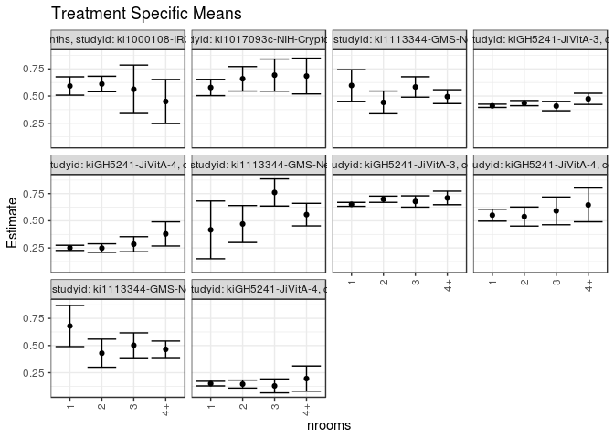

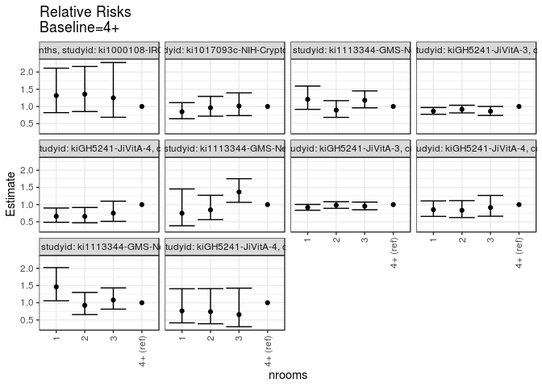

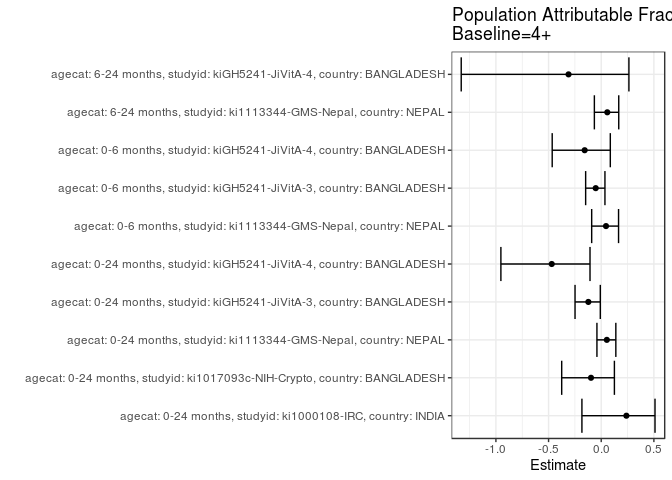

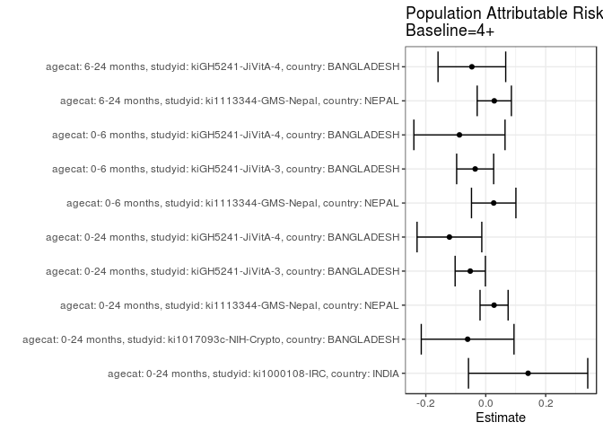

## Results Table

### Parameter: TSM

| agecat | studyid | country | intervention_level | baseline_level | estimate | ci_lower | ci_upper |
| --- | --- | --- | --- | --- | --- | --- | --- |
| 0-24 months | ki1000108-IRC | INDIA | 4+ | NA | 0.4500000 | 0.2471890 | 0.6528110 |
| 0-24 months | ki1000108-IRC | INDIA | 1 | NA | 0.5925926 | 0.5081592 | 0.6770260 |
| 0-24 months | ki1000108-IRC | INDIA | 2 | NA | 0.6111111 | 0.5401543 | 0.6820679 |
| 0-24 months | ki1000108-IRC | INDIA | 3 | NA | 0.5625000 | 0.3398407 | 0.7851593 |
| 0-24 months | ki1017093c-NIH-Crypto | BANGLADESH | 4+ | NA | 0.6842611 | 0.5195188 | 0.8490033 |
| 0-24 months | ki1017093c-NIH-Crypto | BANGLADESH | 1 | NA | 0.5786917 | 0.5036516 | 0.6537317 |
| 0-24 months | ki1017093c-NIH-Crypto | BANGLADESH | 2 | NA | 0.6588431 | 0.5460659 | 0.7716204 |
| 0-24 months | ki1017093c-NIH-Crypto | BANGLADESH | 3 | NA | 0.6927871 | 0.5449231 | 0.8406511 |
| 0-24 months | ki1113344-GMS-Nepal | NEPAL | 4+ | NA | 0.4944795 | 0.4307008 | 0.5582583 |
| 0-24 months | ki1113344-GMS-Nepal | NEPAL | 1 | NA | 0.5973746 | 0.4514345 | 0.7433147 |
| 0-24 months | ki1113344-GMS-Nepal | NEPAL | 2 | NA | 0.4417714 | 0.3374804 | 0.5460623 |
| 0-24 months | ki1113344-GMS-Nepal | NEPAL | 3 | NA | 0.5837510 | 0.4898827 | 0.6776192 |
| 0-24 months | kiGH5241-JiVitA-3 | BANGLADESH | 4+ | NA | 0.4743551 | 0.4231987 | 0.5255115 |
| 0-24 months | kiGH5241-JiVitA-3 | BANGLADESH | 1 | NA | 0.4104887 | 0.3954630 | 0.4255145 |
| 0-24 months | kiGH5241-JiVitA-3 | BANGLADESH | 2 | NA | 0.4351190 | 0.4111084 | 0.4591296 |
| 0-24 months | kiGH5241-JiVitA-3 | BANGLADESH | 3 | NA | 0.4080900 | 0.3652031 | 0.4509768 |
| 0-24 months | kiGH5241-JiVitA-4 | BANGLADESH | 4+ | NA | 0.3792442 | 0.2680558 | 0.4904326 |
| 0-24 months | kiGH5241-JiVitA-4 | BANGLADESH | 1 | NA | 0.2510089 | 0.2272423 | 0.2747755 |
| 0-24 months | kiGH5241-JiVitA-4 | BANGLADESH | 2 | NA | 0.2491464 | 0.2099307 | 0.2883622 |
| 0-24 months | kiGH5241-JiVitA-4 | BANGLADESH | 3 | NA | 0.2848536 | 0.2155968 | 0.3541103 |
| 0-6 months | ki1113344-GMS-Nepal | NEPAL | 4+ | NA | 0.5568182 | 0.4527929 | 0.6608435 |
| 0-6 months | ki1113344-GMS-Nepal | NEPAL | 1 | NA | 0.4166667 | 0.1509081 | 0.6824252 |
| 0-6 months | ki1113344-GMS-Nepal | NEPAL | 2 | NA | 0.4705882 | 0.3004500 | 0.6407264 |
| 0-6 months | ki1113344-GMS-Nepal | NEPAL | 3 | NA | 0.7608696 | 0.6358674 | 0.8858717 |
| 0-6 months | kiGH5241-JiVitA-3 | BANGLADESH | 4+ | NA | 0.7108092 | 0.6483285 | 0.7732900 |
| 0-6 months | kiGH5241-JiVitA-3 | BANGLADESH | 1 | NA | 0.6515308 | 0.6334735 | 0.6695880 |
| 0-6 months | kiGH5241-JiVitA-3 | BANGLADESH | 2 | NA | 0.6987559 | 0.6698207 | 0.7276911 |
| 0-6 months | kiGH5241-JiVitA-3 | BANGLADESH | 3 | NA | 0.6782294 | 0.6261963 | 0.7302625 |
| 0-6 months | kiGH5241-JiVitA-4 | BANGLADESH | 4+ | NA | 0.6461719 | 0.4906102 | 0.8017336 |
| 0-6 months | kiGH5241-JiVitA-4 | BANGLADESH | 1 | NA | 0.5517197 | 0.4968834 | 0.6065561 |
| 0-6 months | kiGH5241-JiVitA-4 | BANGLADESH | 2 | NA | 0.5390770 | 0.4512101 | 0.6269440 |
| 0-6 months | kiGH5241-JiVitA-4 | BANGLADESH | 3 | NA | 0.5913176 | 0.4633280 | 0.7193071 |
| 6-24 months | ki1113344-GMS-Nepal | NEPAL | 4+ | NA | 0.4649670 | 0.3887270 | 0.5412070 |
| 6-24 months | ki1113344-GMS-Nepal | NEPAL | 1 | NA | 0.6796627 | 0.4901438 | 0.8691816 |
| 6-24 months | ki1113344-GMS-Nepal | NEPAL | 2 | NA | 0.4294119 | 0.3002175 | 0.5586062 |
| 6-24 months | ki1113344-GMS-Nepal | NEPAL | 3 | NA | 0.5018237 | 0.3869497 | 0.6166977 |
| 6-24 months | kiGH5241-JiVitA-4 | BANGLADESH | 4+ | NA | 0.1955971 | 0.0796289 | 0.3115652 |
| 6-24 months | kiGH5241-JiVitA-4 | BANGLADESH | 1 | NA | 0.1495972 | 0.1281938 | 0.1710005 |
| 6-24 months | kiGH5241-JiVitA-4 | BANGLADESH | 2 | NA | 0.1448381 | 0.1082029 | 0.1814733 |
| 6-24 months | kiGH5241-JiVitA-4 | BANGLADESH | 3 | NA | 0.1283137 | 0.0643429 | 0.1922845 |

### Parameter: E(Y)

| agecat | studyid | country | intervention_level | baseline_level | estimate | ci_lower | ci_upper |
| --- | --- | --- | --- | --- | --- | --- | --- |
| 0-24 months | ki1000108-IRC | INDIA | NA | NA | 0.5913706 | 0.5391835 | 0.6435576 |
| 0-24 months | ki1017093c-NIH-Crypto | BANGLADESH | NA | NA | 0.6237942 | 0.5698223 | 0.6777662 |
| 0-24 months | ki1113344-GMS-Nepal | NEPAL | NA | NA | 0.5222816 | 0.4773852 | 0.5671781 |
| 0-24 months | kiGH5241-JiVitA-3 | BANGLADESH | NA | NA | 0.4226600 | 0.4115317 | 0.4337883 |
| 0-24 months | kiGH5241-JiVitA-4 | BANGLADESH | NA | NA | 0.2580019 | 0.2386523 | 0.2773515 |
| 0-6 months | ki1113344-GMS-Nepal | NEPAL | NA | NA | 0.5833333 | 0.5108676 | 0.6557991 |
| 0-6 months | kiGH5241-JiVitA-3 | BANGLADESH | NA | NA | 0.6754701 | 0.6621313 | 0.6888089 |
| 0-6 months | kiGH5241-JiVitA-4 | BANGLADESH | NA | NA | 0.5583942 | 0.5167799 | 0.6000084 |
| 6-24 months | ki1113344-GMS-Nepal | NEPAL | NA | NA | 0.4934383 | 0.4388573 | 0.5480193 |
| 6-24 months | kiGH5241-JiVitA-4 | BANGLADESH | NA | NA | 0.1492734 | 0.1316631 | 0.1668838 |

### Parameter: RR

| agecat | studyid | country | intervention_level | baseline_level | estimate | ci_lower | ci_upper |
| --- | --- | --- | --- | --- | --- | --- | --- |
| 0-24 months | ki1000108-IRC | INDIA | 4+ | 4+ | 1.0000000 | 1.0000000 | 1.0000000 |
| 0-24 months | ki1000108-IRC | INDIA | 1 | 4+ | 1.3168724 | 0.8208567 | 2.1126135 |
| 0-24 months | ki1000108-IRC | INDIA | 2 | 4+ | 1.3580247 | 0.8527213 | 2.1627595 |
| 0-24 months | ki1000108-IRC | INDIA | 3 | 4+ | 1.2500000 | 0.6860395 | 2.2775656 |
| 0-24 months | ki1017093c-NIH-Crypto | BANGLADESH | 4+ | 4+ | 1.0000000 | 1.0000000 | 1.0000000 |
| 0-24 months | ki1017093c-NIH-Crypto | BANGLADESH | 1 | 4+ | 0.8457176 | 0.6435062 | 1.1114708 |
| 0-24 months | ki1017093c-NIH-Crypto | BANGLADESH | 2 | 4+ | 0.9628535 | 0.7170252 | 1.2929627 |
| 0-24 months | ki1017093c-NIH-Crypto | BANGLADESH | 3 | 4+ | 1.0124602 | 0.7342939 | 1.3960018 |
| 0-24 months | ki1113344-GMS-Nepal | NEPAL | 4+ | 4+ | 1.0000000 | 1.0000000 | 1.0000000 |
| 0-24 months | ki1113344-GMS-Nepal | NEPAL | 1 | 4+ | 1.2080876 | 0.9159965 | 1.5933200 |
| 0-24 months | ki1113344-GMS-Nepal | NEPAL | 2 | 4+ | 0.8934068 | 0.6828716 | 1.1688517 |
| 0-24 months | ki1113344-GMS-Nepal | NEPAL | 3 | 4+ | 1.1805361 | 0.9602558 | 1.4513482 |
| 0-24 months | kiGH5241-JiVitA-3 | BANGLADESH | 4+ | 4+ | 1.0000000 | 1.0000000 | 1.0000000 |
| 0-24 months | kiGH5241-JiVitA-3 | BANGLADESH | 1 | 4+ | 0.8653617 | 0.7723129 | 0.9696211 |
| 0-24 months | kiGH5241-JiVitA-3 | BANGLADESH | 2 | 4+ | 0.9172854 | 0.8127493 | 1.0352670 |
| 0-24 months | kiGH5241-JiVitA-3 | BANGLADESH | 3 | 4+ | 0.8603048 | 0.7400990 | 1.0000342 |
| 0-24 months | kiGH5241-JiVitA-4 | BANGLADESH | 4+ | 4+ | 1.0000000 | 1.0000000 | 1.0000000 |
| 0-24 months | kiGH5241-JiVitA-4 | BANGLADESH | 1 | 4+ | 0.6618661 | 0.4863504 | 0.9007226 |
| 0-24 months | kiGH5241-JiVitA-4 | BANGLADESH | 2 | 4+ | 0.6569551 | 0.4710066 | 0.9163143 |
| 0-24 months | kiGH5241-JiVitA-4 | BANGLADESH | 3 | 4+ | 0.7511085 | 0.5131955 | 1.0993159 |
| 0-6 months | ki1113344-GMS-Nepal | NEPAL | 4+ | 4+ | 1.0000000 | 1.0000000 | 1.0000000 |
| 0-6 months | ki1113344-GMS-Nepal | NEPAL | 1 | 4+ | 0.7482993 | 0.3849793 | 1.4544986 |
| 0-6 months | ki1113344-GMS-Nepal | NEPAL | 2 | 4+ | 0.8451381 | 0.5625841 | 1.2696027 |
| 0-6 months | ki1113344-GMS-Nepal | NEPAL | 3 | 4+ | 1.3664596 | 1.0654962 | 1.7524342 |
| 0-6 months | kiGH5241-JiVitA-3 | BANGLADESH | 4+ | 4+ | 1.0000000 | 1.0000000 | 1.0000000 |
| 0-6 months | kiGH5241-JiVitA-3 | BANGLADESH | 1 | 4+ | 0.9166043 | 0.8359034 | 1.0050962 |
| 0-6 months | kiGH5241-JiVitA-3 | BANGLADESH | 2 | 4+ | 0.9830428 | 0.8919978 | 1.0833808 |
| 0-6 months | kiGH5241-JiVitA-3 | BANGLADESH | 3 | 4+ | 0.9541652 | 0.8490606 | 1.0722806 |
| 0-6 months | kiGH5241-JiVitA-4 | BANGLADESH | 4+ | 4+ | 1.0000000 | 1.0000000 | 1.0000000 |
| 0-6 months | kiGH5241-JiVitA-4 | BANGLADESH | 1 | 4+ | 0.8538281 | 0.6579658 | 1.1079946 |
| 0-6 months | kiGH5241-JiVitA-4 | BANGLADESH | 2 | 4+ | 0.8342626 | 0.6237126 | 1.1158891 |
| 0-6 months | kiGH5241-JiVitA-4 | BANGLADESH | 3 | 4+ | 0.9151088 | 0.6620052 | 1.2649810 |
| 6-24 months | ki1113344-GMS-Nepal | NEPAL | 4+ | 4+ | 1.0000000 | 1.0000000 | 1.0000000 |
| 6-24 months | ki1113344-GMS-Nepal | NEPAL | 1 | 4+ | 1.4617440 | 1.0570429 | 2.0213896 |
| 6-24 months | ki1113344-GMS-Nepal | NEPAL | 2 | 4+ | 0.9235320 | 0.6560158 | 1.3001385 |
| 6-24 months | ki1113344-GMS-Nepal | NEPAL | 3 | 4+ | 1.0792674 | 0.8136315 | 1.4316285 |
| 6-24 months | kiGH5241-JiVitA-4 | BANGLADESH | 4+ | 4+ | 1.0000000 | 1.0000000 | 1.0000000 |
| 6-24 months | kiGH5241-JiVitA-4 | BANGLADESH | 1 | 4+ | 0.7648231 | 0.4156066 | 1.4074711 |
| 6-24 months | kiGH5241-JiVitA-4 | BANGLADESH | 2 | 4+ | 0.7404922 | 0.3886421 | 1.4108835 |
| 6-24 months | kiGH5241-JiVitA-4 | BANGLADESH | 3 | 4+ | 0.6560102 | 0.3023319 | 1.4234337 |

### Parameter: PAR

| agecat | studyid | country | intervention_level | baseline_level | estimate | ci_lower | ci_upper |
| --- | --- | --- | --- | --- | --- | --- | --- |
| 0-24 months | ki1000108-IRC | INDIA | 4+ | NA | 0.1413706 | -0.0576416 | 0.3403827 |
| 0-24 months | ki1017093c-NIH-Crypto | BANGLADESH | 4+ | NA | -0.0604669 | -0.2152230 | 0.0942893 |
| 0-24 months | ki1113344-GMS-Nepal | NEPAL | 4+ | NA | 0.0278021 | -0.0190342 | 0.0746384 |
| 0-24 months | kiGH5241-JiVitA-3 | BANGLADESH | 4+ | NA | -0.0516951 | -0.1022155 | -0.0011748 |
| 0-24 months | kiGH5241-JiVitA-4 | BANGLADESH | 4+ | NA | -0.1212423 | -0.2292617 | -0.0132229 |
| 0-6 months | ki1113344-GMS-Nepal | NEPAL | 4+ | NA | 0.0265152 | -0.0475959 | 0.1006262 |
| 0-6 months | kiGH5241-JiVitA-3 | BANGLADESH | 4+ | NA | -0.0353391 | -0.0970893 | 0.0264111 |
| 0-6 months | kiGH5241-JiVitA-4 | BANGLADESH | 4+ | NA | -0.0877777 | -0.2399060 | 0.0643505 |
| 6-24 months | ki1113344-GMS-Nepal | NEPAL | 4+ | NA | 0.0284714 | -0.0286139 | 0.0855566 |
| 6-24 months | kiGH5241-JiVitA-4 | BANGLADESH | 4+ | NA | -0.0463236 | -0.1592507 | 0.0666035 |

### Parameter: PAF

| agecat | studyid | country | intervention_level | baseline_level | estimate | ci_lower | ci_upper |
| --- | --- | --- | --- | --- | --- | --- | --- |
| 0-24 months | ki1000108-IRC | INDIA | 4+ | NA | 0.2390558 | -0.1833208 | 0.5106685 |
| 0-24 months | ki1017093c-NIH-Crypto | BANGLADESH | 4+ | NA | -0.0969340 | -0.3753202 | 0.1251025 |
| 0-24 months | ki1113344-GMS-Nepal | NEPAL | 4+ | NA | 0.0532320 | -0.0407876 | 0.1387583 |
| 0-24 months | kiGH5241-JiVitA-3 | BANGLADESH | 4+ | NA | -0.1223091 | -0.2486725 | -0.0087334 |
| 0-24 months | kiGH5241-JiVitA-4 | BANGLADESH | 4+ | NA | -0.4699277 | -0.9526987 | -0.1065135 |
| 0-6 months | ki1113344-GMS-Nepal | NEPAL | 4+ | NA | 0.0454545 | -0.0906256 | 0.1645556 |
| 0-6 months | kiGH5241-JiVitA-3 | BANGLADESH | 4+ | NA | -0.0523178 | -0.1478904 | 0.0352974 |
| 0-6 months | kiGH5241-JiVitA-4 | BANGLADESH | 4+ | NA | -0.1571967 | -0.4654860 | 0.0862388 |
| 6-24 months | ki1113344-GMS-Nepal | NEPAL | 4+ | NA | 0.0576999 | -0.0650967 | 0.1663391 |
| 6-24 months | kiGH5241-JiVitA-4 | BANGLADESH | 4+ | NA | -0.3103274 | -1.3293372 | 0.2628986 |